# Reproducible Project

Atul Katoch

07 May 2023

## Introduction

Basketball is a popular team sport played worldwide, with two teams of five players each competing to score points by shooting a ball through a hoop elevated 10 feet above the ground. The game is played on a rectangular court with a hoop at each end, and the team with the most points at the end of the game is declared the winner.

Some key metrics used in basketball include points scored, rebounds, assists, steals, and blocks. Points are scored when a player successfully shoots the ball through the hoop, with each shot counting for two or three points depending on where the shot was taken from on the court. Rebounds occur when a player grabs a missed shot or a ball that bounces off the backboard, with offensive rebounds giving the team another opportunity to score. Assists are awarded when a player passes the ball to a teammate who then scores, while steals and blocks refer to defensive actions that prevent the opposing team from scoring.

There are five positions in basketball: - point guard - shooting guard - small forward - power forward and - center. Each position has specific requirements and responsibilities:

**Point guard**: Generally the smallest player on the court, the point guard is responsible for bringing the ball up the court and initiating the team’s offense. They must be quick and agile, with excellent ball-handling skills and the ability to make quick decisions under pressure.

**Shooting guard**: Typically a taller player than the point guard, the shooting guard is often the team’s best perimeter shooter and scorer. They must be able to create their own shot and move well without the ball to get open for shots.

**Small forward**: A versatile player who can play inside or outside, the small forward is often tasked with guarding the opposing team’s best player. They must be able to score from the perimeter and also drive to the basket, as well as rebound and defend.

**Power forward**: Generally a strong, physical player who can play inside and outside, the power forward is responsible for scoring and rebounding in the post, as well as defending the opposing team’s big men.

**Center**: The tallest player on the court, the center is responsible for scoring and rebounding in the post, as well as protecting the rim on defense. They must be strong, physical, and able to defend against the opposing team’s big men.

Scenario of this project is to as a data analyst provide data analytic information to the Chicago Bulls competing in the NBA(National Basketball Association), that can help the team to win trophies. Chicago Bulls are not doing very well recently in the NBA, they are placed 27th out of 30 based on the win-loss record. The budget allocated to the 2019-20 season is $118Million to find best 5 starting players and data analyst have to be careful not to spend all of the money on these 5 players there should be money for the subsitute players as well.

The job given to the data analyst is to find the best five [starting players](https://en.wikipedia.org/wiki/Basketball_positions)Chicago Bulls can afford which can help to improve their ranking in the league and can challenge and aim to win the championship.

I have been provided with the 2018-19 season data that include the nba player statistics, player salary, team payroll and teams statistics as well.

I strongly believe that the data analysis of the given datasets will help in monitoring player performance, game strategy and above all the talent identification who is still within the budget range and can help the team to win the trophies.

This project is very important because data gathering, data analysis of the Athletes can provide valuable insights that can help teams optimize player performance and develop game strategies that give them a competitive edge.

### Load the relevant libraries

```r
library(tidyverse)
```

```r
library(dplyr)
library(broom)
library(ggplot2)
library(car)
```

### Read the data using the ‘read_csv()’ function

The dataset variables description can be found [here](https://uclearn.canberra.edu.au/courses/13262/pages/data-description-reproducible-data-analysis-project)

```r
df1 <- read_csv("data/raw/2018-19_nba_team-statistics_1.csv")
```

```
## ──────────────────────────────────────────────────────── Delimiter: "," chr
## (1): Team dbl (21): Rk, Age, W, L, PW, PL, MOV, SOS, SRS, ORtg, DRtg, NRtg,
## Pace, FTr,... lgl (3): ...23, ...24, ...25
```

```r
df2 <- read_csv("data/raw/2018-19_nba_team-statistics_2.csv")
df3 <- read_csv("data/raw/2018-19_nba_player-statistics.csv")
df4 <- read_csv("data/raw/2018-19_nba_player-salaries.csv")
team_pyrl <- read_csv("data/raw/2019-20_nba_team-payroll.csv")
```

### Remove the undesirable columns that dont help in data analysis.

```r
df1 <- select(df1, - Rk)
```

```r
df1 <- df1[, 1:(ncol(df1)-3)]
```

Every team played 82 games, the G column can be deleted. Ranking column Rk can be deleted as well

```r
df2 <- select(df2, -c(Rk, G))
```

In df3 dataframe player stats are listed. There is duplicate rows issue here. We need to first fix the duplicate rows for the players who were traded during the season. These players have the row with ‘TOT’ in team column. This row is their total. I am deleting rows with TOT in team and then add duplicate rows.

```r
df3 <- df3[!df3$Tm == 'TOT',]
```

Fixing the position variable (Pos) and adding position number instead this will be required to change from multiple position intrchangeable positions (some player play more than in one position)to fixed 5 positions.

```r
df3$Pos[df3$Pos == "PG"] <- "1"
df3$Pos[df3$Pos == "SG"] <- "2"
df3$Pos[df3$Pos == "SG-PF"] <- "2"
df3$Pos[df3$Pos == "SG-SF"] <- "2"
df3$Pos[df3$Pos == "SF"] <- "3"
df3$Pos[df3$Pos == "SF-SG"] <- "3"
df3$Pos[df3$Pos == "PF"] <- "4"
df3$Pos[df3$Pos == "PF-C"] <- "4"
df3$Pos[df3$Pos == "PF-SF"] <- "4"
df3$Pos[df3$Pos == "C"] <- "5"
df3$Pos[df3$Pos == "C-PF"] <- "5"
```

Delete Team column as its not required

```r
df3 <-select(df3, -c(Tm))
```

add all numbers of duplicate rows and show a one unique row. remeber we have already deleted the rows where Tm == TOT

### Questions to answer

1. Do teams that take more offensive rebounds win more games?
2. Do teams that take more defensive rebounds win more games?
3. Do teams that score more 3 pointers win more games?
4. Do teams that score more 2 pointers win more games?
5. Do teams that steal more win more games?
6. Do teams that have more assists win more games?
7. Check the multicollinerarity

```r
df3<- df3 %>%
  group_by(player_name, Pos) %>%
  summarise(across(everything(), sum))
```

check if the function to sum all variables for duplicate rows working fine I checked the data and Ryan Anderson total sum of 3PA is 40

```r
my_chk <- sum(subset(df3, player_name == "Ryan Anderson")$'3PA')
my_chk
```

```
## [1] 40
```

The check complete the code is working fine. 3PA total is 40.

### Joining data

```r
nba_team_data <- left_join(df1, df2, by = c("Team"))
```

### Check the header and tail of the dataset

```r
head(df)
```

[output not shown]

```r
tail(df)
```

[output not shown]

### Replace 3 with letter three

```r
names(nba_team_data) <- str_replace_all(string = names(nba_team_data),
                                             pattern = "3",
                                             replacement = "three_")
```

### Replace 2 with letter two

```r
names(nba_team_data) <- str_replace_all(string = names(nba_team_data),
                                             pattern = "2",
                                             replacement = "two_")
```

### Remove special chr in the col names

```r
names(nba_team_data) <- str_replace_all(string = names(nba_team_data),
                                      pattern = "%",
                                      replacement = "_pct")
```

### Make all varibale names lowercase

```r
names(nba_team_data) <- tolower(names(nba_team_data))
```

same exercise for player stats but first join the player stat and their salary dataframes ### Join dataframe 3 and 4 detailing player’s stat and salary

```r
player_stat <- left_join(df3, df4, by = c("player_name"))
```

### Replace 3 with letter three

```r
names(player_stat) <- str_replace_all(string = names(player_stat),
                                        pattern = "3",
                                        replacement = "three_")
```

### Replace 2 with letter two

```r
names(player_stat) <- str_replace_all(string = names(player_stat),
                                        pattern = "2",
                                        replacement = "two_")
```

### Remove special chr in the col names

```r
names(player_stat) <- str_replace_all(string = names(player_stat),
                                        pattern = "%",
                                        replacement = "_pct")
```

### Make all varibale names lowercase

```r
names(player_stat) <- tolower(names(player_stat))
```

### Check the Nas

```r
sum(is.na(nba_team_data))
```

```
## [1] 0
```

no Nas

### Check the header using ‘head()’ function

```r
head(nba_team_data)
```

```
## # A tibble: 6 × 43
##   team     age     w     l    pw    pl   mov   sos   srs  ortg  drtg  nrtg  pace
##   <chr>  <dbl> <dbl> <dbl> <dbl> <dbl> <dbl> <dbl> <dbl> <dbl> <dbl> <dbl> <dbl>
## 1 Milwa…  26.9    60    22    61    21  8.87 -0.82  8.04  114.  105.   8.6 103.
## 2 Golde…  28.4    57    25    56    26  6.46 -0.04  6.42  116.  110.   6.4 101.
## 3 Toron…  27.3    58    24    56    26  6.09 -0.6   5.49  113.  107.   6   100.
## 4 Utah …  27.3    50    32    54    28  5.26  0.03  5.28  111.  106.   5.2 100.
## 5 Houst…  29.2    53    29    53    29  4.77  0.19  4.96  116.  111.   4.8  97.9
## 6 Portl…  26.2    53    29    51    31  4.2   0.24  4.43  115.  110.   4.2  99.1
## # ℹ 30 more variables: ftr <dbl>, three_par <dbl>, ts_pct <dbl>, efg_pct <dbl>,
## #   tov_pct <dbl>, orb_pct <dbl>, `ft/fga` <dbl>, drb_pct <dbl>, mp <dbl>,
## #   fg <dbl>, fga <dbl>, fg_pct <dbl>, three_p <dbl>, three_pa <dbl>,
## #   three_p_pct <dbl>, two_p <dbl>, two_pa <dbl>, two_p_pct <dbl>, ft <dbl>,
## #   fta <dbl>, ft_pct <dbl>, orb <dbl>, drb <dbl>, trb <dbl>, ast <dbl>,
## #   stl <dbl>, blk <dbl>, tov <dbl>, pf <dbl>, pts <dbl>
```

### Check the tail of the dataset using the ‘tail()’ function

```r
tail(nba_team_data)
```

```
## # A tibble: 6 × 43
##   team     age     w     l    pw    pl   mov   sos   srs  ortg  drtg  nrtg  pace
##   <chr>  <dbl> <dbl> <dbl> <dbl> <dbl> <dbl> <dbl> <dbl> <dbl> <dbl> <dbl> <dbl>
## 1 Washi…  26.5    32    50    34    48 -2.9  -0.4  -3.3   111.  114.  -2.8 101.
## 2 Atlan…  25.1    29    53    27    55 -6.02 -0.04 -6.06  108.  114.  -5.8 104.
## 3 Chica…  24      22    60    21    61 -8.41  0.1  -8.32  105.  113.  -8.4  99
## 4 Phoen…  24      19    63    19    63 -9.34  0.73 -8.61  106.  115.  -9.2 100.
## 5 New Y…  23.4    17    65    19    63 -9.21  0.28 -8.93  104.  114.  -9.2  99.6
## 6 Cleve…  25.2    19    63    19    63 -9.61  0.22 -9.39  108.  118.  -9.9  96.6
## # ℹ 30 more variables: ftr <dbl>, three_par <dbl>, ts_pct <dbl>, efg_pct <dbl>,
## #   tov_pct <dbl>, orb_pct <dbl>, `ft/fga` <dbl>, drb_pct <dbl>, mp <dbl>,
## #   fg <dbl>, fga <dbl>, fg_pct <dbl>, three_p <dbl>, three_pa <dbl>,
## #   three_p_pct <dbl>, two_p <dbl>, two_pa <dbl>, two_p_pct <dbl>, ft <dbl>,
## #   fta <dbl>, ft_pct <dbl>, orb <dbl>, drb <dbl>, trb <dbl>, ast <dbl>,
## #   stl <dbl>, blk <dbl>, tov <dbl>, pf <dbl>, pts <dbl>
```

### Check the structure of the dataset using ‘str()’ function

```r
str(nba_team_data)
```

```
## tibble [30 × 43] (S3: tbl_df/tbl/data.frame)
##  $ team       : chr [1:30] "Milwaukee Bucks" "Golden State Warriors" "Toronto Raptors" "Utah Jazz" ...
##  $ age        : num [1:30] 26.9 28.4 27.3 27.3 29.2 26.2 24.9 25.7 25.7 27 ...
##  $ w          : num [1:30] 60 57 58 50 53 53 54 49 49 48 ...
##  $ l          : num [1:30] 22 25 24 32 29 29 28 33 33 34 ...
##  $ pw         : num [1:30] 61 56 56 54 53 51 51 52 50 50 ...
##  $ pl         : num [1:30] 21 26 26 28 29 31 31 30 32 32 ...
##  $ mov        : num [1:30] 8.87 6.46 6.09 5.26 4.77 4.2 3.95 4.44 3.4 3.33 ...
##  $ sos        : num [1:30] -0.82 -0.04 -0.6 0.03 0.19 0.24 0.24 -0.54 0.15 -0.57 ...
##  $ srs        : num [1:30] 8.04 6.42 5.49 5.28 4.96 4.43 4.19 3.9 3.56 2.76 ...
##  $ ortg       : num [1:30] 114 116 113 111 116 ...
##  $ drtg       : num [1:30] 105 110 107 106 111 ...
##  $ nrtg       : num [1:30] 8.6 6.4 6 5.2 4.8 4.2 4.1 4.4 3.3 3.4 ...
##  $ pace       : num [1:30] 103.3 100.9 100.2 100.3 97.9 ...
##  $ ftr        : num [1:30] 0.255 0.227 0.247 0.295 0.279 0.258 0.232 0.215 0.266 0.242 ...
```

[output cut: 29 more lines]

## Exploratory Data Analysis

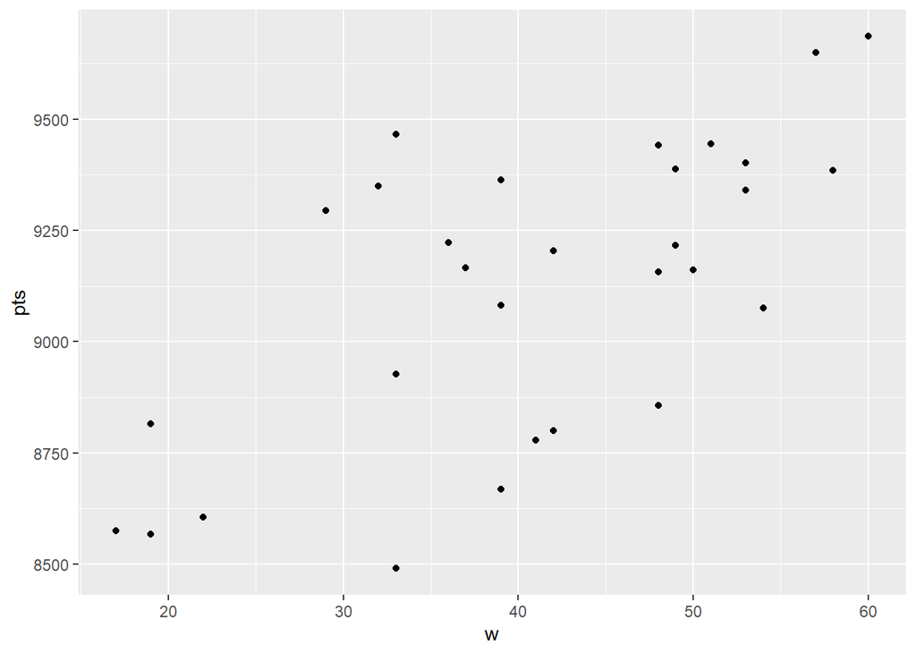

```r
ggplot(data = nba_team_data, aes( x = w, y = pts ))+
  geom_point()
```

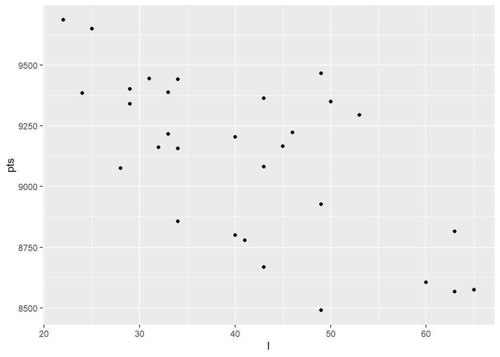

```r
ggplot(data = nba_team_data, aes( x = l, y = pts ))+
  geom_point()
```

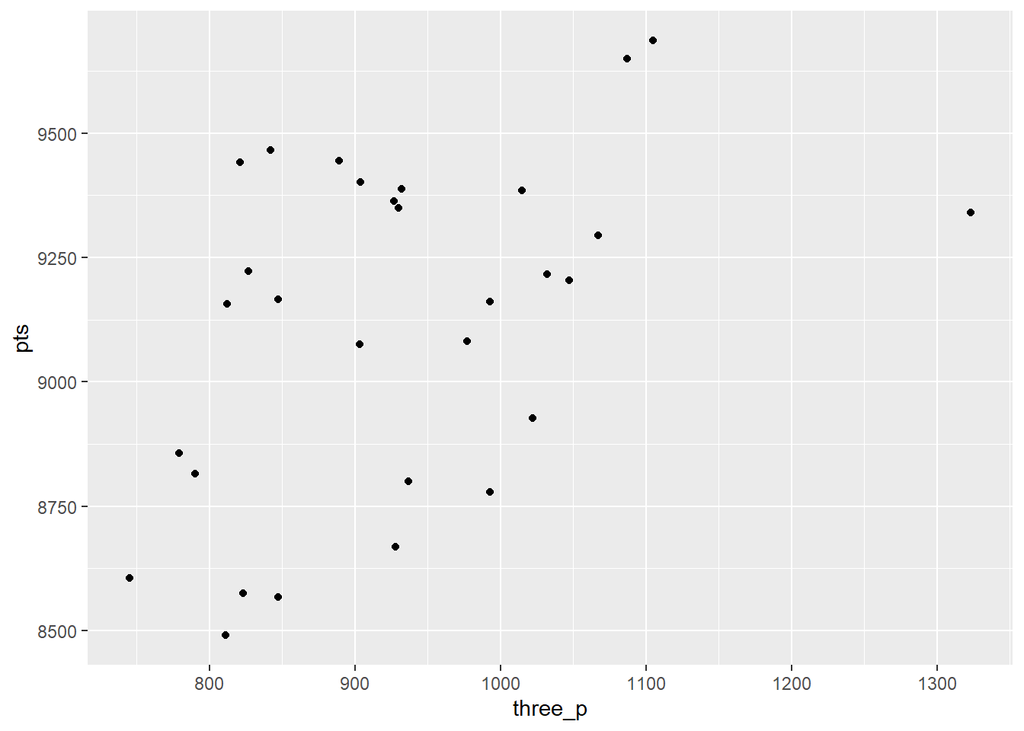

```r
ggplot(data = nba_team_data, aes( x = three_p, y = pts ))+
  geom_point()
```

fg (field goals) variable have strong positive correlation strength with points. more field goals will likely to win the game.

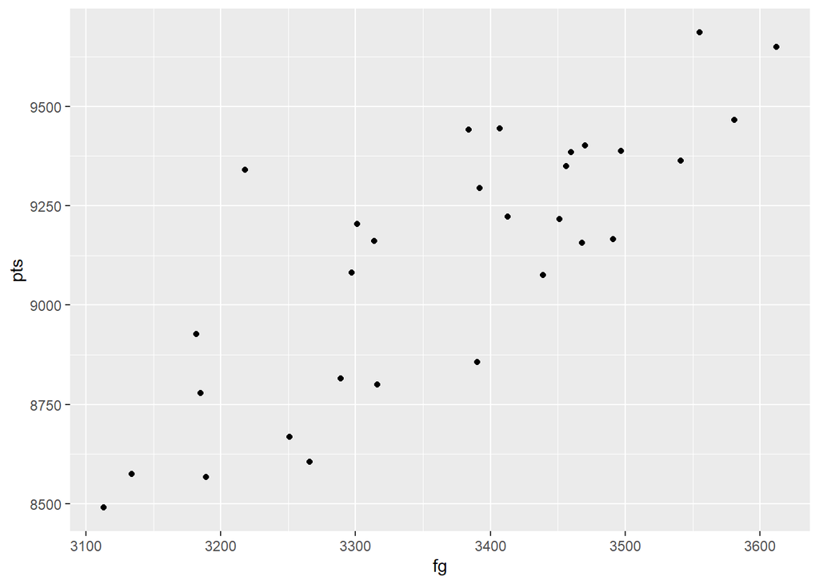

```r
ggplot(data = nba_team_data, aes( x = fg, y = pts ))+
  geom_point()
```

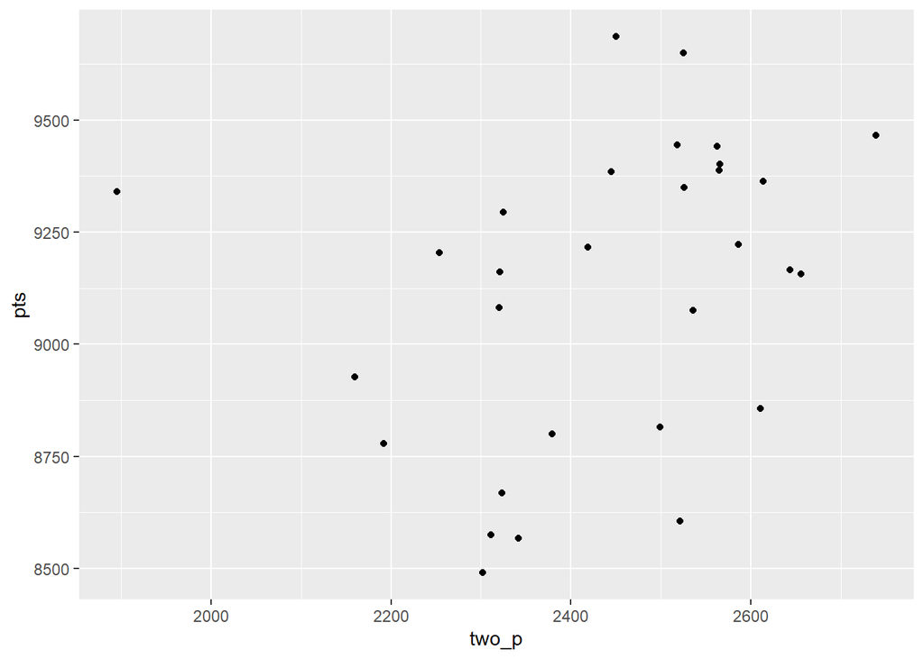

```r
ggplot(data = nba_team_data, aes( x = two_p, y = pts ))+
  geom_point()
```

tov (turnover) variable have no correlation strength with points.

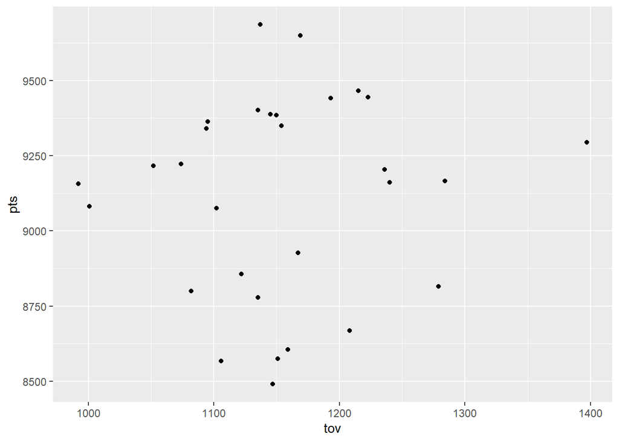

```r
ggplot(data = nba_team_data, aes( x = tov, y = pts ))+
  geom_point()
```

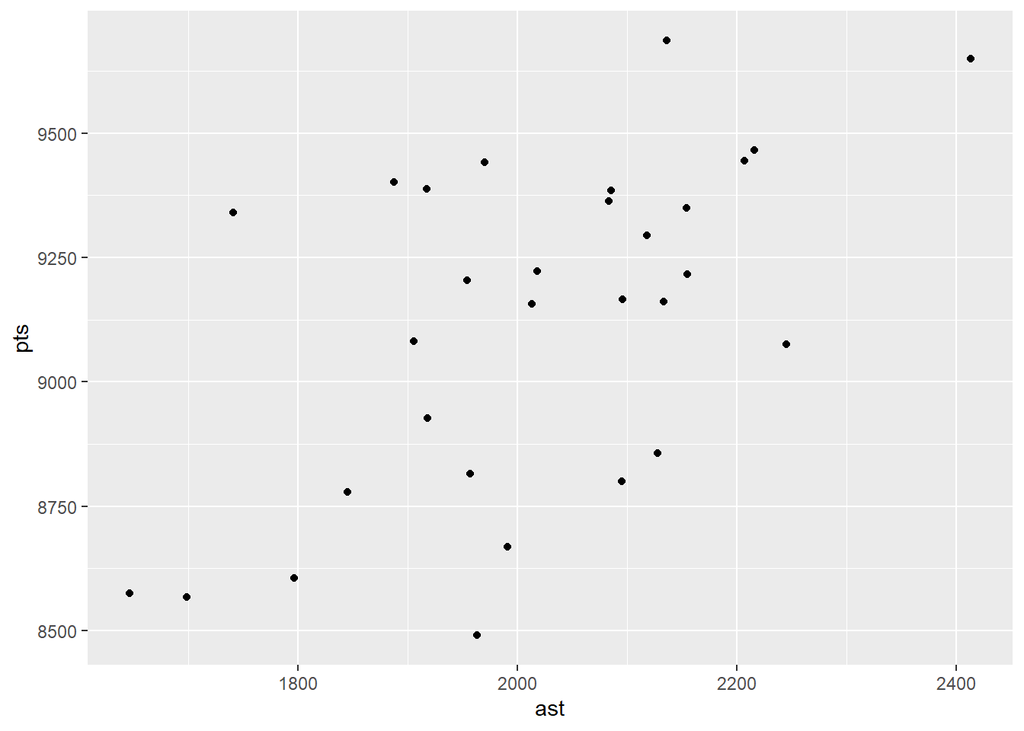

```r
ggplot(data = nba_team_data, aes( x = ast, y = pts ))+
  geom_point()
```

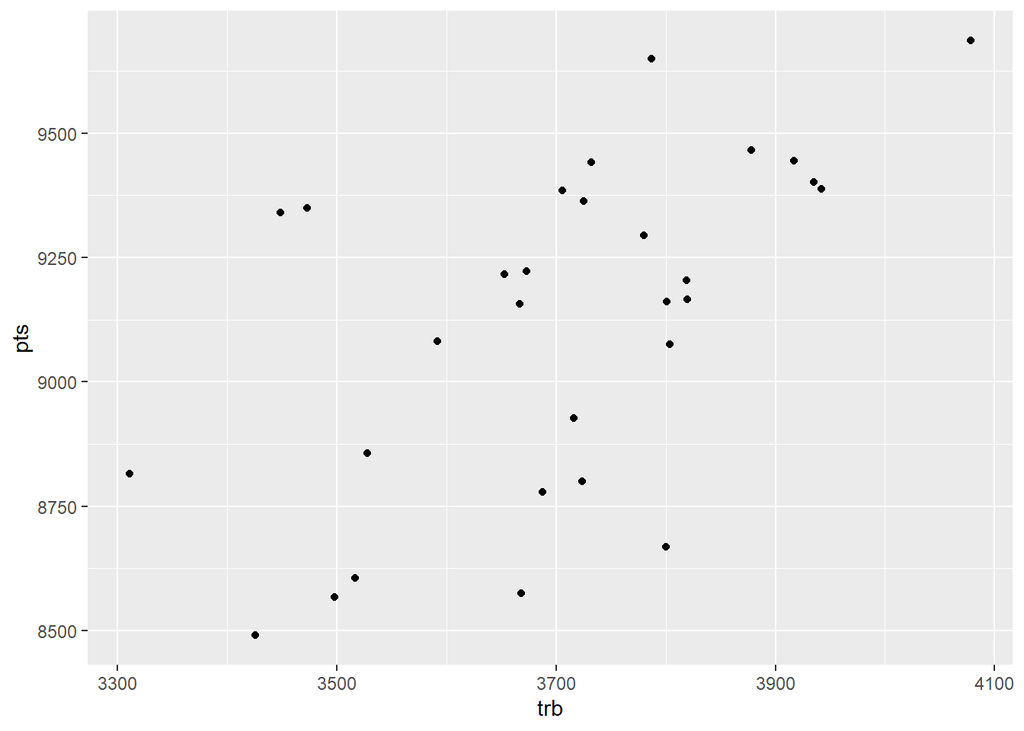

```r
ggplot(data = nba_team_data, aes( x = trb, y = pts ))+
  geom_point()
```

blk variable have weak positive correlation strength with points. more blocks will likely to win the game.

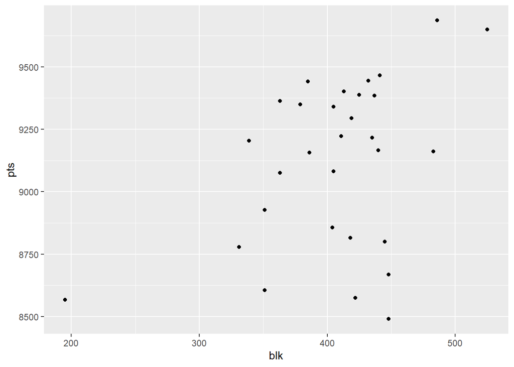

```r
ggplot(data = nba_team_data, aes( x = blk, y = pts ))+
  geom_point()
```

stl variable have no correlation with points.

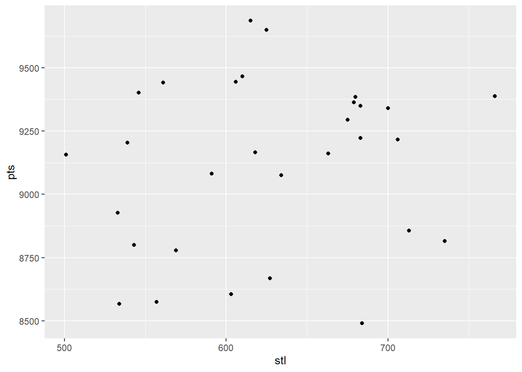

```r
ggplot(data = nba_team_data, aes( x = stl, y = pts ))+
  geom_point()
```

I chose the above variables based on the fact that these variables are also present in the player stat dataset

## Correlation

calculate the correlation matrix

```r
cor_matrix <- cor(nba_team_data[,c(3:42)])
```

### Display the correlation matrix

```r
print(cor_matrix)
```

```
##                       w           l           pw           pl          mov
## w            1.00000000 -1.00000000  0.980495890 -0.980495890  0.979708646
## l           -1.00000000  1.00000000 -0.980495890  0.980495890 -0.979708646
## pw           0.98049589 -0.98049589  1.000000000 -1.000000000  0.999054375
## pl          -0.98049589  0.98049589 -1.000000000  1.000000000 -0.999054375
## mov          0.97970865 -0.97970865  0.999054375 -0.999054375  1.000000000
## sos         -0.48811009  0.48811009 -0.500786152  0.500786152 -0.500051994
## srs          0.97737210 -0.97737210  0.996384482 -0.996384482  0.997421670
## ortg         0.84113222 -0.84113222  0.820782943 -0.820782943  0.819861525
## drtg        -0.75978281  0.75978281 -0.811879149  0.811879149 -0.814123661
## nrtg         0.98003619 -0.98003619  0.998972686 -0.998972686  0.999760898
## pace         0.08892848 -0.08892848  0.093487134 -0.093487134  0.097361920
## ftr          0.02345929 -0.02345929  0.007002387 -0.007002387  0.008520192
## three_par    0.28432694 -0.28432694  0.336260980 -0.336260980  0.338328489
## ts_pct       0.75710305 -0.75710305  0.742196037 -0.742196037  0.743822620
## efg_pct      0.78186438 -0.78186438  0.786534009 -0.786534009  0.787099876
## tov_pct     -0.30687747  0.30687747 -0.305109900  0.305109900 -0.309505811
## orb_pct      0.23543113 -0.23543113  0.215414477 -0.215414477  0.203757467
## ft/fga       0.08609194 -0.08609194  0.043882043 -0.043882043  0.045963754
## drb_pct      0.44833352 -0.44833352  0.464139674 -0.464139674  0.469008579
## mp          -0.14438499  0.14438499 -0.203237734  0.203237734 -0.196996882
## fg           0.52595661 -0.52595661  0.515331784 -0.515331784  0.515968740
## fga          0.16797328 -0.16797328  0.165823153 -0.165823153  0.166757316
## fg_pct       0.61083275 -0.61083275  0.596923411 -0.596923411  0.596739432
## three_p      0.48387734 -0.48387734  0.512436060 -0.512436060  0.514076924
## three_pa     0.31262805 -0.31262805  0.362490538 -0.362490538  0.364817675
## three_p_pct  0.54185988 -0.54185988  0.465948190 -0.465948190  0.463415791
## two_p        0.06870566 -0.06870566  0.040778175 -0.040778175  0.040131061
## two_pa      -0.21816440  0.21816440 -0.266426011  0.266426011 -0.268197099
## two_p_pct    0.60093959 -0.60093959  0.647744866 -0.647744866  0.649862308
## ft           0.12976860 -0.12976860  0.084537460 -0.084537460  0.087006760
## fta          0.06228760 -0.06228760  0.044417311 -0.044417311  0.046048832
## ft_pct       0.16116078 -0.16116078  0.102991057 -0.102991057  0.104202746
## orb          0.07860702 -0.07860702  0.063912610 -0.063912610  0.054491510
## drb          0.57488402 -0.57488402  0.587282068 -0.587282068  0.599172307
## trb          0.52874938 -0.52874938  0.532531329 -0.532531329  0.538330581
## ast          0.50187524 -0.50187524  0.521274837 -0.521274837  0.523403885
## stl          0.10202691 -0.10202691  0.147945092 -0.147945092  0.138916219
## blk          0.44488840 -0.44488840  0.495696163 -0.495696163  0.508438933
## tov         -0.24713530  0.24713530 -0.250504586  0.250504586 -0.254921367
```

[output cut: 273 more lines]

```
## three_p_pct  0.284360637 -0.165131316  0.0530990102 -0.370835726 -0.180262368
## two_p        0.491831387  0.085431699  0.1651403324 -0.004762771 -0.160053239
## two_pa       0.138656450 -0.050729089 -0.1159954961 -0.109839628 -0.160283438
## two_p_pct    0.625365975  0.286007312  0.5583302306  0.197323588  0.032021065
## ft          -0.153955291 -0.118126149  0.0047380095  0.172333289  0.384182283
## fta         -0.131626703 -0.022825779  0.0247622653  0.374826511  0.487730335
## ft_pct      -0.047602626 -0.219481383 -0.0406310623 -0.469636953 -0.246995887
## orb         -0.036913238  0.006602362 -0.1824338448  0.153056516  0.217162591
## drb          0.463270216 -0.270270204  0.5063512204  0.130829980 -0.214312845
## trb          0.379472561 -0.228326615  0.3486903860  0.183183373 -0.082507688
## ast          1.000000000  0.259884798  0.5556639698  0.177553630 -0.055471465
## stl          0.259884798  1.000000000  0.3535669647  0.165973401  0.425769941
## blk          0.555663970  0.353566965  1.0000000000  0.191857923  0.077429349
## tov          0.177553630  0.165973401  0.1918579231  1.000000000  0.678648282
## pf          -0.055471465  0.425769941  0.0774293489  0.678648282  1.000000000
```

### Load the corrplot library

```r
library(corrplot)
```

### Create a correlation matrix plot

[figure not shown]

```r
corrplot(cor_matrix, method="color", type="lower", order="hclust", tl.cex=0.7, tl.col="black", addCoef.col="black")
```

correlation between three points and points

```r
cor(x = nba_team_data$three_p, y = nba_team_data$pts, method = "pearson")
```

```
## [1] 0.4565562
```

0.4565

correlation between field goal and points

```r
cor(x = nba_team_data$fg, y = nba_team_data$pts, method = "pearson")
```

```
## [1] 0.816435
```

0.8164 - very strong relationship

correlation between two pointer and points

```r
cor(x = nba_team_data$two_p, y = nba_team_data$pts, method = "pearson")
```

```
## [1] 0.3105844
```

0.3105

correlation between assist and points

```r
cor(x = nba_team_data$ast, y = nba_team_data$pts, method = "pearson")
```

```
## [1] 0.5653053
```

0.5653

correlation between block and points

```r
cor(x = nba_team_data$blk, y = nba_team_data$pts, method = "pearson")
```

```
## [1] 0.409453
```

0.4094

### Linear regression

let us visualise it using ggplot() function

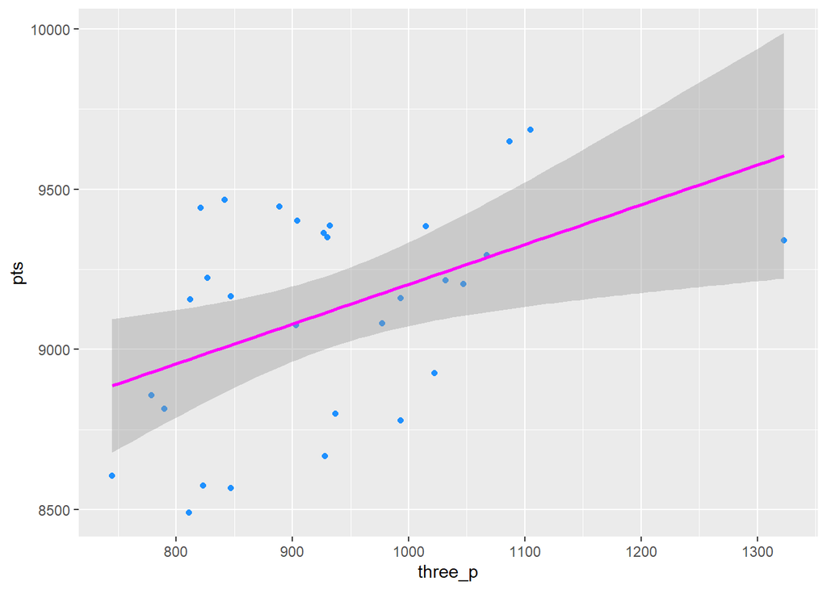

```r
lm_plot1 <- ggplot(nba_team_data, aes(x = three_p, y = pts)) +
  geom_point(colour = "dodgerblue")+
  geom_smooth(method = "lm", colour = "magenta")

lm_plot1
```

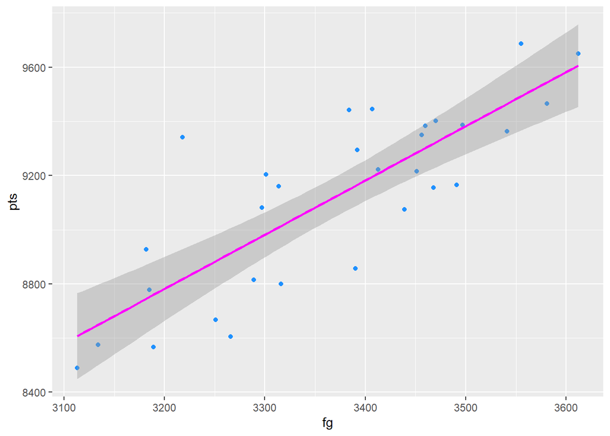

```r
lm_plot2 <- ggplot(nba_team_data, aes(x = fg, y = pts)) +
  geom_point(colour = "dodgerblue")+
  geom_smooth(method = "lm", colour = "magenta")

lm_plot2
```

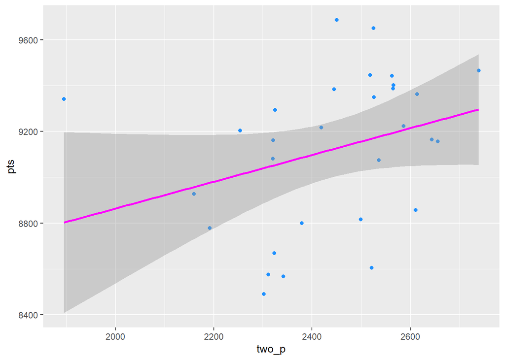

```r
lm_plot3 <- ggplot(nba_team_data, aes(x = two_p, y = pts)) +
  geom_point(colour = "dodgerblue")+
  geom_smooth(method = "lm", colour = "magenta")

lm_plot3
```

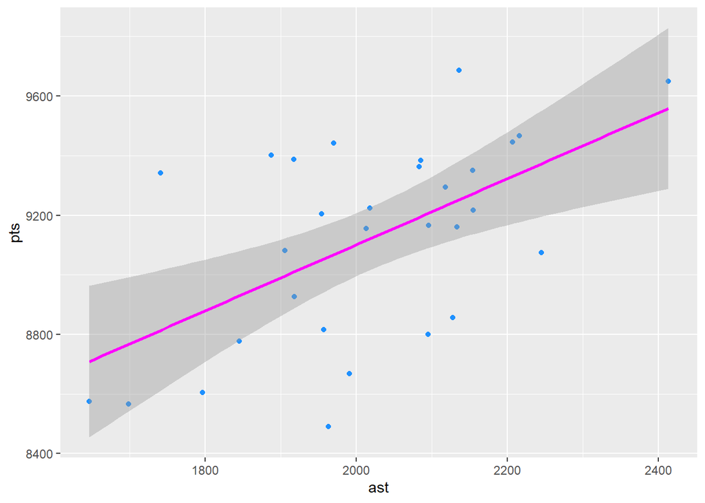

```r
lm_plot4 <- ggplot(nba_team_data, aes(x = ast, y = pts)) +
  geom_point(colour = "dodgerblue")+
  geom_smooth(method = "lm", colour = "magenta")

lm_plot4
```

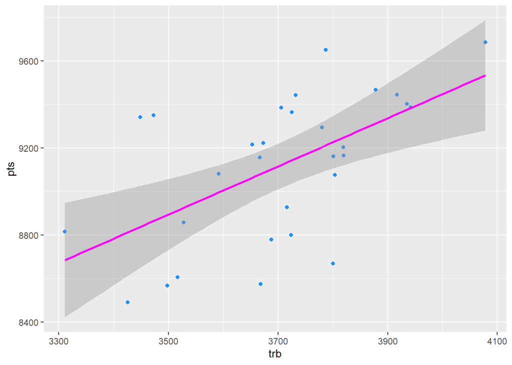

```r
lm_plot5 <- ggplot(nba_team_data, aes(x = trb, y = pts)) +
  geom_point(colour = "dodgerblue")+
  geom_smooth(method = "lm", colour = "magenta")

lm_plot5
```

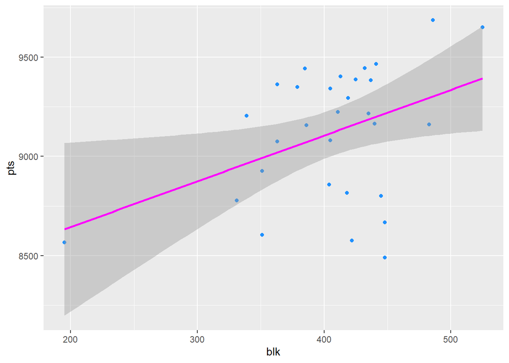

```r
lm_plot6 <- ggplot(nba_team_data, aes(x = blk, y = pts)) +
  geom_point(colour = "dodgerblue")+
  geom_smooth(method = "lm", colour = "magenta")

lm_plot6
```

### Use ‘pairs()’ function to check multicollinearity

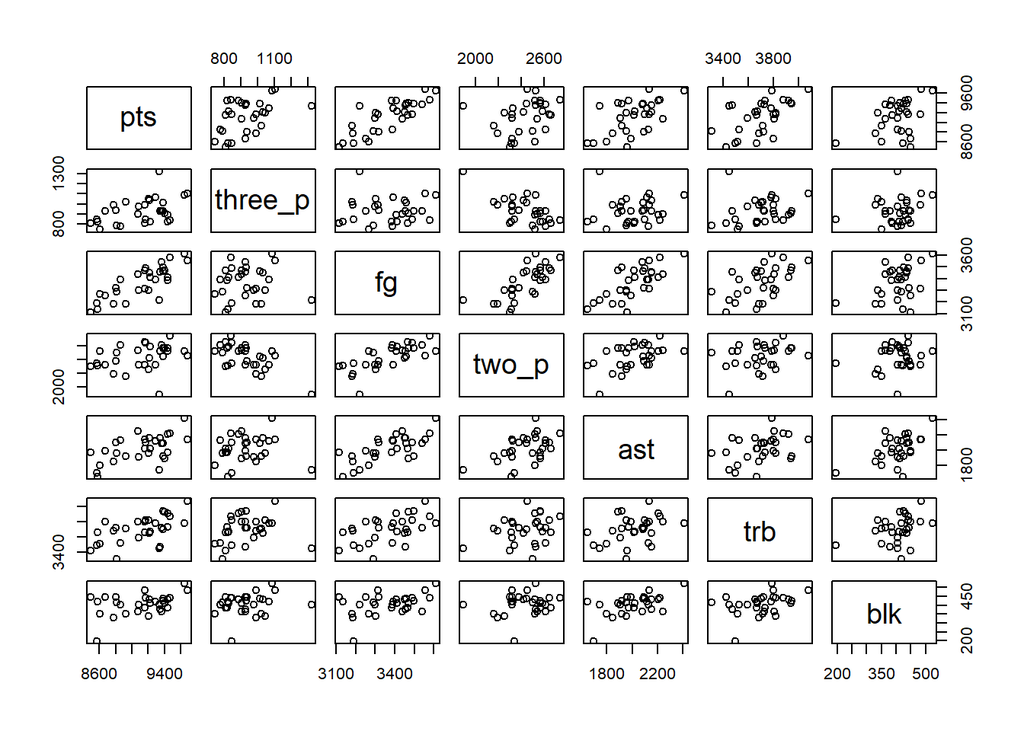

```r
pairs(formula = pts ~ three_p + fg + two_p + ast + trb + blk, data = nba_team_data)
```

**There are some assumptions that we need to be careful of:** - The response variable should be continuous (i.e. ratio/interval)

- There are two or more explanatory variables that are either continuous or categorical
- There should be independence of observations
- There should be a linear relationship between the response variable and each explanatory variable
- There should be no significant outliers, influential or high leverage points
- The data needs to show homoscedasticity
- The residuals should be normally distributed
- There should not be multicollinearity between the explanatory variables

## Multiple linear regression Modelling

```r
fit <- lm(pts ~ three_p + fg + two_p + ast + trb + blk, data = nba_team_data)
tidy(fit, conf.int = TRUE)
```

```
## # A tibble: 7 × 7
##   term        estimate std.error statistic     p.value conf.low conf.high
##   <chr>          <dbl>     <dbl>     <dbl>       <dbl>    <dbl>     <dbl>
## 1 (Intercept) 1164.      774.        1.51   0.145      -432.     2761.
## 2 three_p        1.06      0.230     4.62   0.000108      0.589     1.54
## 3 fg             2.01      0.322     6.25   0.00000184    1.35      2.68
## 4 two_p         NA        NA        NA     NA            NA        NA
## 5 ast           -0.233     0.257    -0.906  0.374        -0.763     0.298
## 6 trb            0.154     0.194     0.796  0.434        -0.246     0.555
## 7 blk            0.184     0.568     0.325  0.748        -0.987     1.36
```

```r
summary(fit)
```

```
##
## Call:
## lm(formula = pts ~ three_p + fg + two_p + ast + trb + blk, data = nba_team_data)
##
## Residuals:
##     Min      1Q  Median      3Q     Max
## -238.33  -85.98  -16.57   68.15  398.88
##
## Coefficients: (1 not defined because of singularities)
##              Estimate Std. Error t value Pr(>|t|)
## (Intercept) 1164.4620   773.7210   1.505 0.145368
## three_p        1.0642     0.2302   4.624 0.000108 ***
## fg             2.0143     0.3222   6.251 1.84e-06 ***
## two_p              NA         NA      NA       NA
## ast           -0.2328     0.2571  -0.906 0.374176
## trb            0.1544     0.1940   0.796 0.433757
## blk            0.1845     0.5677   0.325 0.748033
## ---
## Signif. codes:  0 '***' 0.001 '**' 0.01 '*' 0.05 '.' 0.1 ' ' 1
##
## Residual standard error: 147 on 24 degrees of freedom
## Multiple R-squared:  0.8412, Adjusted R-squared:  0.8081
## F-statistic: 25.42 on 5 and 24 DF,  p-value: 7.369e-09
```

**Predicted value**

```r
head(predict(fit))
```

```
##        1        2        3        4        5        6
## 9723.208 9716.636 9381.466 9075.950 9256.292 9360.511
```

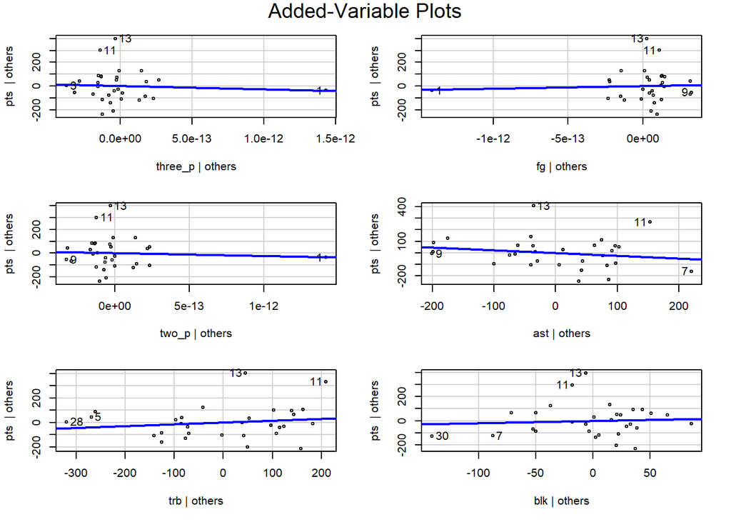

```r
car::avPlots(fit)
```

**Check multicollenearity**

Multicollinearity occurs when two or more of your explanatory variables are highly related with each other It can lead to changes in the coefficient estimates and confusion around which variable is explaining the variance in the response variable

### Variance inflation factor

commenting out as the code is not working for some reasons. It was working before, due to the time shortage i am not able to debug it.

```r
#car::vif(fit)

#sqrt(car::vif(fit))
```

### Outliers

Detecting outliers using ‘rstandard()’ function

```r
std_res <- rstandard(fit)
points <- 1:length(std_res)
```

**visualise it**

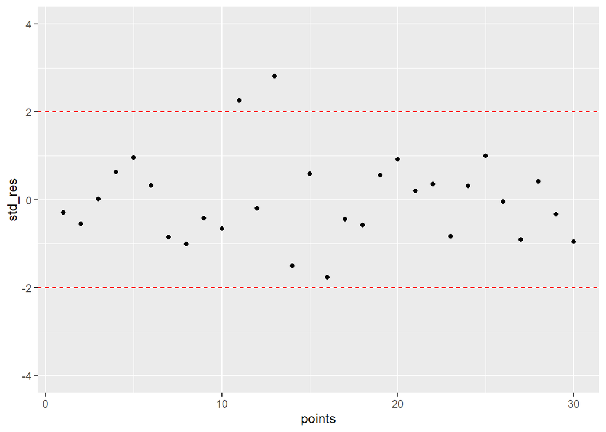

```r
ggplot(nba_team_data, aes(x = points, y = std_res)) +
  geom_point() +
  ylim(c(-4, 4)) +
  geom_hline(yintercept = c(-2, 2), colour = "red", linetype = "dashed")
```

```r
res_labels <- if_else(abs(std_res) >= 1, paste(points), "")
```

**visualising the point of interest**

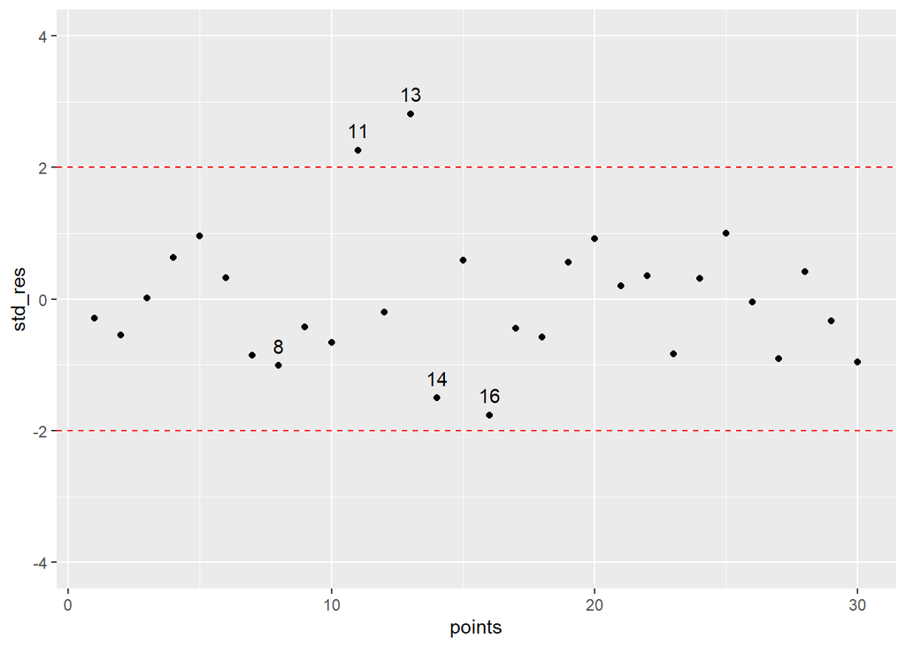

```r
ggplot(data = NULL, aes(x = points, y = std_res)) +
  geom_point() +
  geom_text(aes(label = res_labels), nudge_y = 0.3) +
  ylim(c(-4, 4)) +
  geom_hline(yintercept = c(-2, 2), colour = "red", linetype = "dashed")
```

Leverage points can be checked using hatvalues() function ‘hat’ values are between 0 and 1 with larger values indicating greater potential for leverage

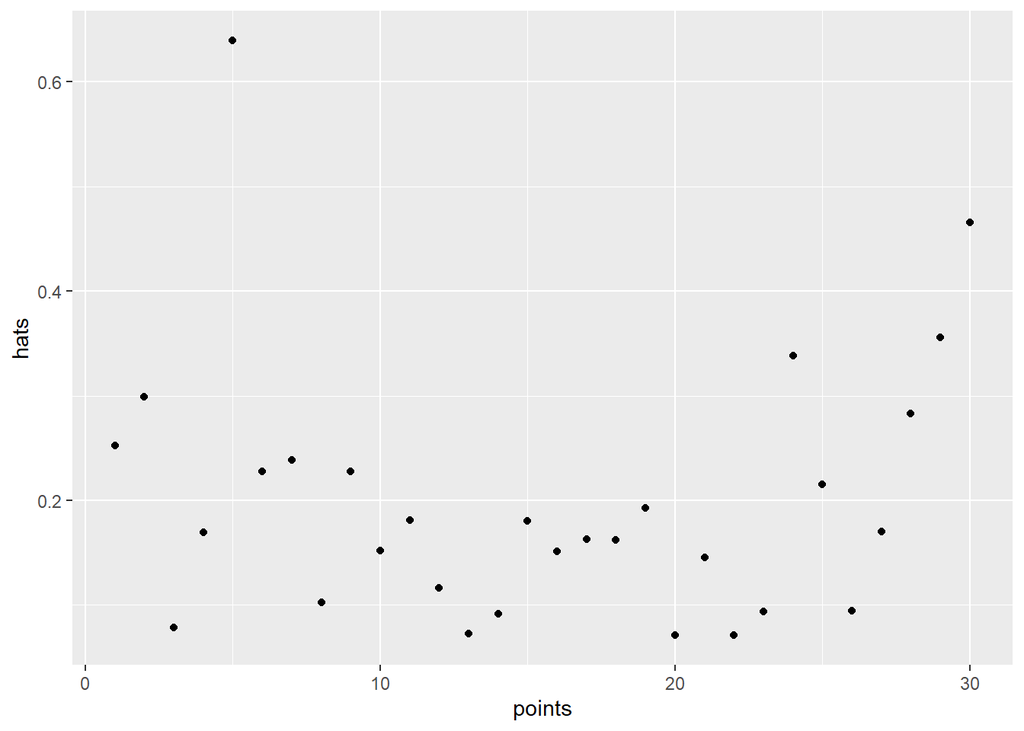

```r
hats <- hatvalues(fit)

ggplot(data = NULL, aes(x = points, y = hats)) +
  geom_point()
```

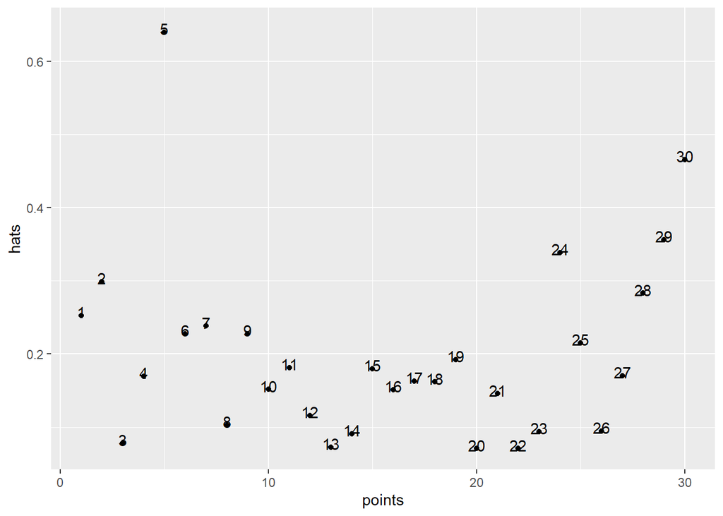

```r
hat_labels <- if_else(hats >= 0.01, paste(points), "")

ggplot(data = NULL, aes(x = points, y = hats)) +
  geom_point() +
  geom_text(aes(label = hat_labels), nudge_y = 0.005)
```

**cooks distance is calucalted to check the change in the coefficient when the ithpoint is deleted**

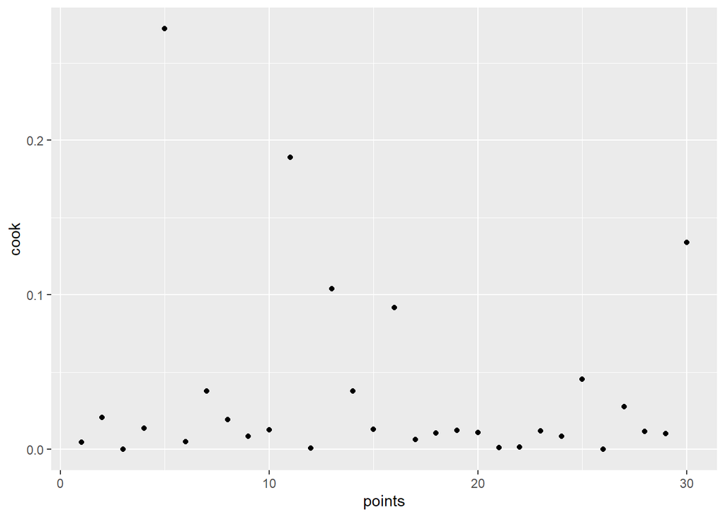

```r
cook <- cooks.distance(fit)

ggplot(data = NULL, aes(x = points, y = cook)) +
  geom_point()
```

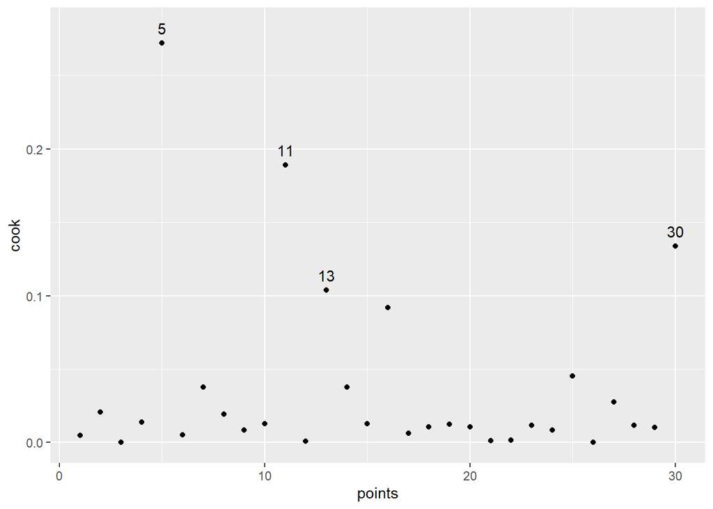

```r
cook_label <- if_else(cook >= 0.1, paste(points), "")

ggplot(data = NULL, aes(x = points, y = cook)) +
  geom_point() +
  geom_text(aes(label  = cook_label), nudge_y = 0.01)
```

**independence of observations**

```r
durbinWatsonTest(fit)
```

```
##  lag Autocorrelation D-W Statistic p-value
##    1      -0.2123832      2.401582    0.24
##  Alternative hypothesis: rho != 0
```

*Homoscedasticity indicates the constant variance among residuals on all values of x variable*

```r
res <- residuals(fit)
fitted <- predict(fit)
```

**Visualise it**

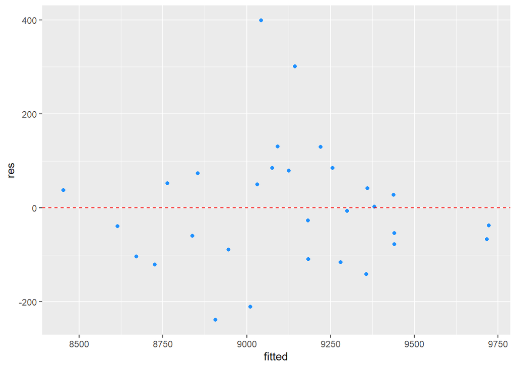

```r
ggplot(data = NULL, aes(x = fitted, y = res)) +
  geom_point(colour = "dodgerblue") +
  geom_hline(yintercept = 0, colour = "red", linetype = "dashed")
```

**Check the normality of residuals**

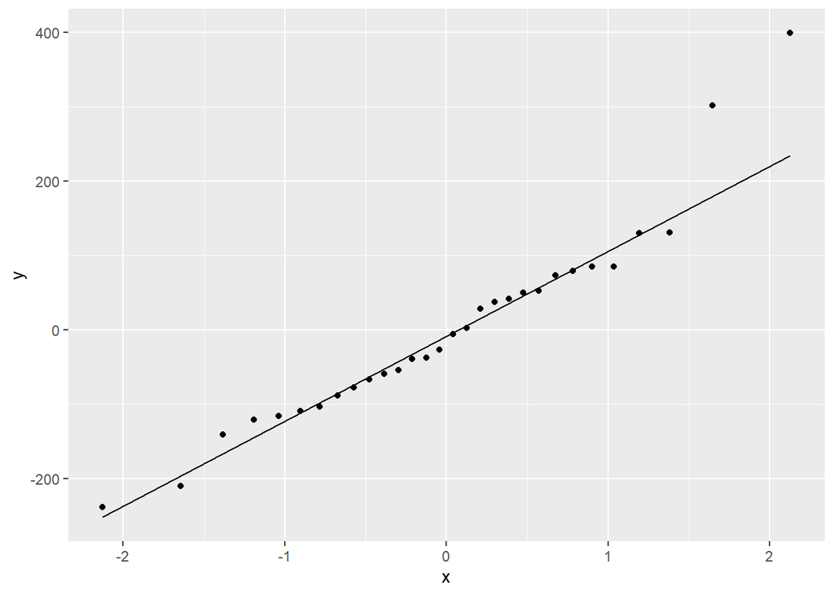

```r
ggplot(data = NULL, aes(sample = res)) +
  stat_qq() + stat_qq_line()
```

### Model Testing

Expected runs player metric

```r
new_data <- nba_team_data %>%
  select(team, w, pts, three_p, fg, two_p, ast, trb, blk)
```

```r
new_data <- mutate(new_data, exp_pts = predict(fit, newdata = new_data))
```

**Visualise it**

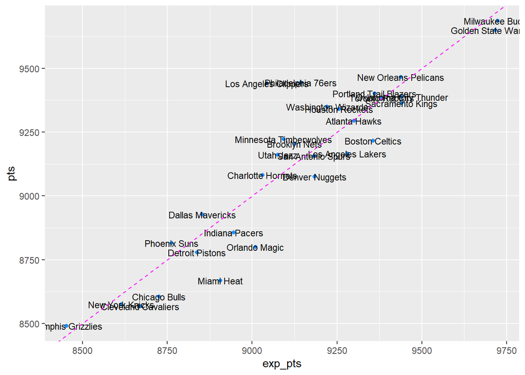

```r
ggplot(new_data, aes(exp_pts, pts, label = team)) +
  geom_point(colour = "dodgerblue") +
  geom_text(nudge_x = 0.1, cex = 3) +
  geom_abline(linetype = "dashed", colour = "magenta")
```

Expected points

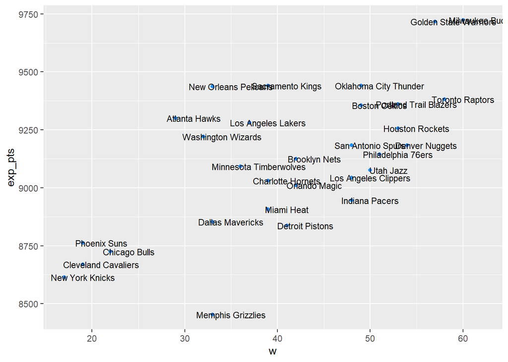

```r
ggplot(new_data, aes(x = w, y = exp_pts, label = team)) +
  geom_point(colour = "dodgerblue") +
  geom_text(nudge_x = 2, cex = 3)
```

Adding player stat data to complete the data analysis

```r
players <- select(player_stat, - player_name)
players$player_name <- NULL

players <- mutate(players, exp_Pts = predict(fit, newdata = players))
```

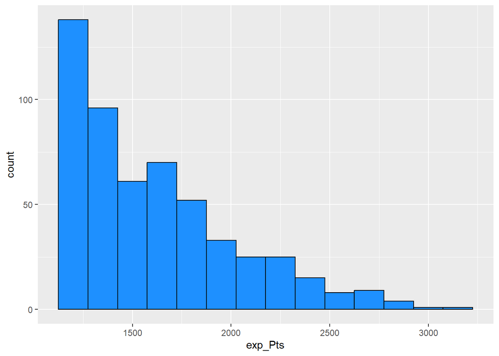

```r
players %>%
  ggplot(aes(x = exp_Pts)) +
  geom_histogram(binwidth = 150, colour = "black", fill = "dodgerblue")
```

```r
players %>%
  select(player_id, pos, salary, exp_Pts) %>%
  arrange(desc(exp_Pts), salary) %>%
  top_n(10)
```

```
## # A tibble: 10 × 4
##    player_id pos     salary exp_Pts
##        <dbl> <chr>    <dbl>   <dbl>
##  1       224 1     30570000   3219.
##  2       197 3     30560700   2929.
##  3        43 2     25434262   2896.
##  4       539 1     12000000   2863.
##  5       522 5      7839435   2797.
##  6       132 1     37457154   2792.
##  7       535 5     12750000   2759.
##  8       517 2     18988725   2752.
##  9       160 3     30000000   2748.
## 10       244 2      3833760   2737.
```

Join the players table with player stat table using player_id to get the player name

```r
best_five <- left_join(players, df4, by = c("player_id"))

final_dataset <- best_five %>%
  select(player_name, pos, salary.x, exp_Pts)

final_dataset
```

```
## # A tibble: 538 × 4
##    player_name     pos   salary.x exp_Pts
##    <chr>           <chr>    <dbl>   <dbl>
##  1 Aaron Gordon    4     21590909   2272.
##  2 Aaron Holiday   1      1914480   1414.
##  3 Abdel Nader     3      1378242   1397.
##  4 Al Horford      5     28928710   2042.
##  5 Al-Farouq Aminu 4      6957105   1860.
##  6 Alan Williams   4        77250   1183.
##  7 Alec Burks      2     11536515   1626.
##  8 Alex Abrines    2      3667645   1325.
##  9 Alex Caruso     1        77250   1339.
## 10 Alex Len        5      4350000   1946.
## # ℹ 528 more rows
```

```r
recommendations <- final_dataset %>%
  arrange(desc(exp_Pts), salary.x) %>%
  top_n(25)
recommendations
```

```
## # A tibble: 25 × 4
##    player_name        pos   salary.x exp_Pts
##    <chr>              <chr>    <dbl>   <dbl>
##  1 James Harden       1     30570000   3219.
##  2 Paul George        3     30560700   2929.
##  3 Bradley Beal       2     25434262   2896.
##  4 Kemba Walker       1     12000000   2863.
##  5 Karl-Anthony Towns 5      7839435   2797.
##  6 Stephen Curry      1     37457154   2792.
##  7 Nikola Vucevic     5     12750000   2759.
##  8 Klay Thompson      2     18988725   2752.
##  9 Kevin Durant       3     30000000   2748.
## 10 Buddy Hield        2      3833760   2737.
## # ℹ 15 more rows
```

### Player Recommendations to the club:

After careful analysis i have picked

- *Kemba Walker* for position 1 which is Point Guard and take salary of $12Million
- *Buddy Hield* for position 2 which is Shooting Guard, salary 3.8M
- *Kevin Durant* for position 3 which is Small Forward, salary 30M
- *Tobias Harris* for position 4 which is Power Forward, salary 14.8M
- *Karl-Anthony Tov* position 5 which is Centre, salary $7,839,435.00

**Total Expenses $68,473,893.00**

The whole final dataset was based on the specific traits of the players like 3point shooting ability, 2 points, field goals, assits ability, total rebounds and blocks for defence.

Player was chosen based on their expected points and salary. Some of the player were real bargain for their price.

### Summary

In This project, we analysed 5 different datasets related to NBA statistics and player statistics and their salary. Overall, this project demonstrates how data analysis and statistical modeling can be applied to gain insights into sports performance and inform decision-making processes in the sports industry. Note that the approach taken in this project is just one possible method (using the best traits required for various position the player are bought for) for selecting the best players within a budget constraint, and there are other approaches and factors to consider (such as team chemistry, play style, opponent matchup and injury history etc).